# Reproducible Research: Peer Assessment 1

## Loading and preprocessing the data

Load the data (i.e. read.csv())

```r
data <- read.csv("activity.csv", na.strings="NA", stringsAsFactors=FALSE)

library("plyr")
library("dplyr")
```

## What is mean total number of steps taken per day?

Make a histogram of the total number of steps taken each day

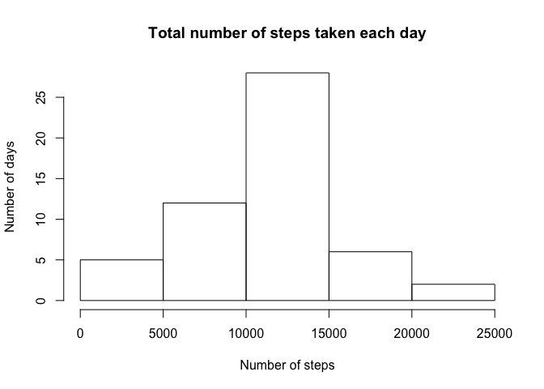

```r
steps_pr_day <- data %>%
     group_by(date) %>%
     summarise(Tot.steps = sum(steps))

hist(steps_pr_day$Tot.steps, main="Total number of steps taken each day", xlab="Number of steps", ylab="Number of days")
```

Calculated and reported the mean:

```r
mean(steps_pr_day$Tot.steps, na.rm=TRUE)
```

```
## [1] 10766.19
```

Calculated and reported the median:

```r
median(steps_pr_day$Tot.steps, na.rm=TRUE)
```

```
## [1] 10765
```

## What is the average daily activity pattern?

A time series plot (i.e. type = “l”) of the 5-minute interval (x-axis) and the average number of steps taken, averaged across all days (y-axis)

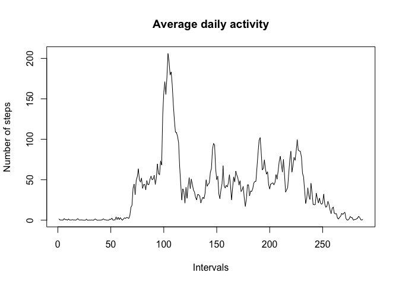

```r
steps_pr_interval <- data %>%
     group_by(interval) %>%
     summarise(mean.steps = mean(steps, na.rm=TRUE))

plot(steps_pr_interval$mean.steps, type="l", main="Average daily activity", xlab="Intervals", ylab="Number of steps")
```

The 5-minute interval, that on average across all the days in the dataset, contains the maximum number of steps:

```r
which.max(steps_pr_interval$mean.steps)
```

```
## [1] 104
```

## Imputing missing values

Calculated and reported the total number of missing values in the dataset (i.e. the total number of rows with NAs):

```r
sum(is.na(data$steps))
```

```
## [1] 2304
```

My strategy for filling in all of the missing values in the dataset is to use the mean for that 5-minute interval and insert it where it is missing.

Created a new dataset that is equal to the original dataset but with the missing data filled in:

```r
cleaned_data <- data
steps_pr_interval_extended <- steps_pr_interval[rep(seq_len(nrow(steps_pr_interval)), 61), ]
for (i in 1:nrow(data) ) {
        if(is.na(data[i,1])) {
                cleaned_data[i,1] <- as.integer(steps_pr_interval_extended[i,2])
        }
}
```

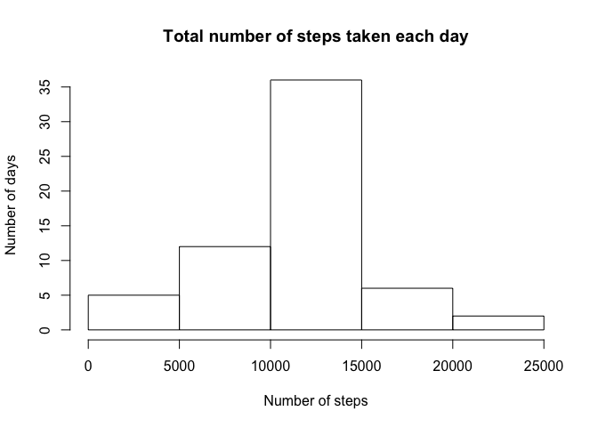

```r
steps_pr_day_cleaned <- cleaned_data %>%
     group_by(date) %>%
     summarise(Tot.steps = sum(steps))

hist(steps_pr_day_cleaned$Tot.steps, main="Total number of steps taken each day", xlab="Number of steps", ylab="Number of days")
```

Calculated and reported the mean with imputed values:

```r
mean(steps_pr_day_cleaned$Tot.steps)
```

```
## [1] 10749.77
```

Calculated and reported the median with imputed values:

```r
median(steps_pr_day_cleaned$Tot.steps)
```

```
## [1] 10641
```

## Are there differences in activity patterns between weekdays and weekends?

Created a new factor variable in the dataset with two levels – “weekday” and “weekend” indicating whether a given date is a weekday or weekend day.

```r
cleaned_data$day <- c("weekend", "weekday", "weekday", "weekday", "weekday", "weekday", "weekend")[as.POSIXlt(cleaned_data$date)$wday + 1]
cleaned_data$day <- as.factor(cleaned_data$day)
```

Made a panel plot containing a time series plot (i.e. type = “l”) of the 5-minute interval (x-axis) and the average number of steps taken, averaged across all weekday days or weekend days (y-axis).

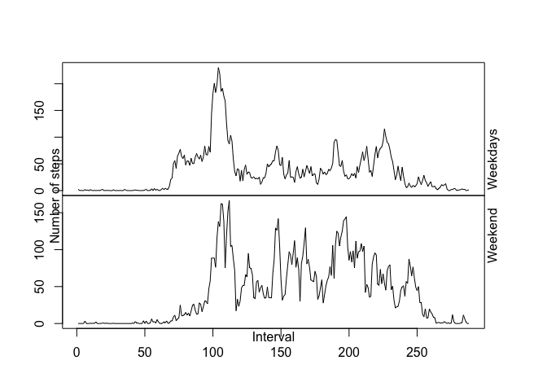

```r
weekdays <- cleaned_data[which(cleaned_data$day=="weekday"),]
weekends <- cleaned_data[which(cleaned_data$day=="weekend"),]

steps_pr_weekday <- weekdays %>%
     group_by(interval) %>%
     summarise(mean.steps = mean(steps))

steps_pr_weekend <- weekends %>%
     group_by(interval) %>%
     summarise(mean.steps = mean(steps))


par(mfrow=c(2,1))
par(mar = c(0, 0, 0, 0), oma = c(4, 4, 4, 4))
plot(steps_pr_weekday$mean.steps, type="l", xaxt='n')
plot(steps_pr_weekend$mean.steps, type="l")
mtext("Interval", side = 1, outer = TRUE)
mtext("Weekend     Weekdays", side = 4, outer = TRUE)
mtext("Number of steps", side = 2, outer = TRUE)
```